# Tutorial Instalación R y RStudio en Windows

Es necesario que siga al pie de la letra estos pasos, principalmente para que primero sea instalado el lenguaje R y luego RStudio.

### Instalación R

1. Descargue el archivo que contiene R en su última versión desde el siguiente enlace. Si anteriormente ha instalado R, igualmente se recomienda descargar la última versión. Enlace: https://cran.r-project.org/bin/windows/base/
2. Abrir archivo descargado, que debe tener un nombre similar a “R-4.4.3-win.exe”. Nota: Preste atención a que no seleccione el archivo descargado de RStudio.

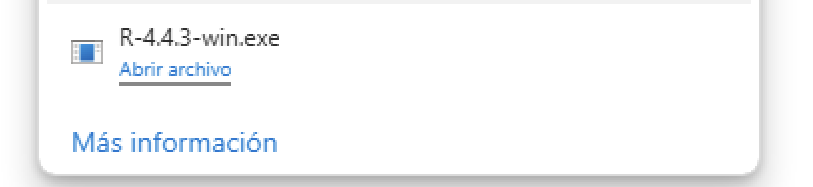

3. Seleccionar idioma de instalación “español” y hacer clic en “aceptar”:

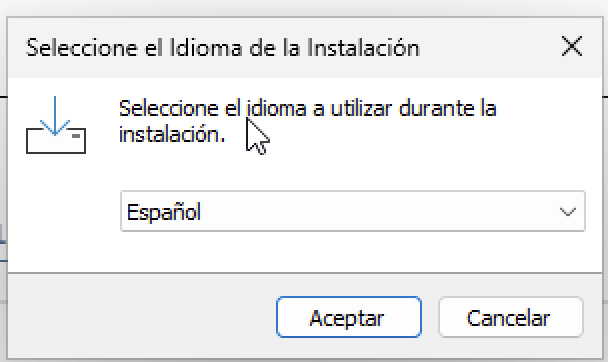

4. Dar clic en “Siguiente” referente a aceptar los términos de la licencia de instalación:

[figure not shown]

5. Dar clic en “Siguiente” en la ruta de instalación predeterminada, la cual generalmente es “Program Files” o “Archivos de Programa”:

[figure not shown]

6. Verificar que estén seleccionados los tres componentes mostrados en la imagen y dar clic en “Siguiente”:

[figure not shown]

7. Seleccionar “No” (seleccionada por defecto) en opciones de configuración, y hacer clic en “Siguiente”:

[figure not shown]

8. En “Seleccione la Carpeta del Menú de Inicio”, dejar los valores que muestra por defecto y hacer clic en “Siguiente”:

[figure not shown]

9. Esperar a que se instalen los archivos - dependencias:

[figure not shown]

10. Una vez finalizada la instalación aparecerá esta pantalla. Verificar que no indique que se ha generado un error. En caso de aparecer algún mensaje o advertencia de que pudo ocurrir un error al hacer la instalación, es necesario que haga una captura de pantalla y la comparta con el instructor-profesor del curso. En caso de no mostrar error, hacer clic en “Finalizar” :

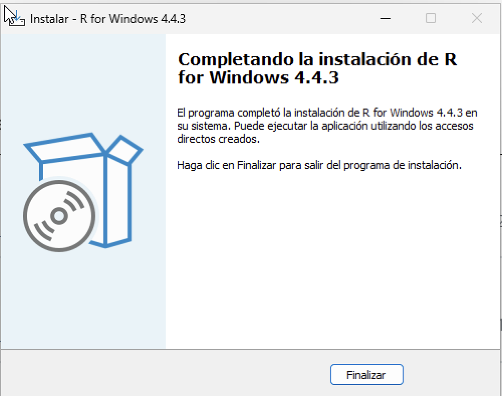

### Instalación RStudio:

RStudio es el entorno de desarrollo integrado que se usará para dar soporte a la generación y desarrollo de códigos en R. Estos son los pasos a seguir para instalarlo:

1. Ir a la página https://posit.co/download/rstudio-desktop/ y descargar la opción correspondiente a su sistema operativo. En caso de windows 10 u 11:

[figure not shown]

2. Hacer clic en “Siguiente” al aparecer el asistente de instalación:

[figure not shown]

[figure not shown]

4. Una vez finalizada la instalación aparecerá esta pantalla. Verificar que no indique que se ha generado un error. En caso de aparecer algún mensaje o advertencia de que pudo ocurrir un error al hacer la instalación, es necesario que haga una captura de pantalla y la comparta con el instructor-profesor del curso. En caso de no mostrar error, hacer clic en “Terminar” :

[figure not shown]

5. Para verificar que se instaló correctamente RStudio vaya a su “Escritorio” o a “Programas”, busque el icono de RStudio, similar al que se muestra en la siguiente imagen y abra el programa.

[figure not shown]